# Reproducible Research

LTC Cade Saie

May 20, 2016

# Have you heard or said any of these?

- Can you show me how you did that?
- Can you share the code?
- I dont understand what you did.
- I would like to build upon that.
- I think that would be a great way to do XXXX

# What is it?

Reproducible analysis means that data analyses are documented with their data and code so that others may verify the methods and findings and also enhance or build upon them. This provides transparency, which is the foundation of effective analysis underpinning both validity and reproducibility.

# Why it is important

- Collaboration with others
- Documentation
- Re-use

# How to do it using R

- Sweave does this with LaTeX
- knitr builds on Sweave
- Can use Python, Awk, Ruby, Haskell, Bash, Perl, Graphviz, TikZ, SAS, Scala, and CoffeeScript.
- An explanation of the program logic in a natural language, interspersed with snippets of code.
- Donald Knuth introduced literate programming to allow programmers to develop programs in the order demanded by the logic and flow of their thoughts rather than the needs of the computer.

# RMarkdown

[figure not shown]

# $\LaTeX$

RMarkdown fully integrates $\LaTeX$

- $$M=
  \begin{bmatrix}
  1 & 2 & 3 & 4 & 5 \\
  3 & 4 & 5 & 6 & 7
  \end{bmatrix}$$
- \begin{equation*} 0=\min_{u \in U} \left[g(x,u)+\nabla_{t}J^*(t,x) + \nabla_{x}J^*(t,x)^{\prime} f(x,u)\right],~\forall~t,x \end{equation*}

  with the boundary condition of:
  $$J^*(T,x)=h(x)$$
  If we can solve this equation we are able to elicit an optimal control strategy $\forall~t,x$
- Just out of curiosity….Does anyone recognize this PDE?

# HTML

- So you can use HTML too [Show me Shiny](http://www.showmeshiny.com/)
- Broadcast Shiny Apps

[interactive chart not shown]

# Advanced topics

Cascading Style Sheets files

- Describes the presentation of a document written in a markup language.
- It is how these slides were made
- Can be confusing and difficult
- Not a very well documented internet subject
- Looks like this
- body{ font-size: 18px; letter-spacing: -1px; line-height: 2; font-weight: normal; font-style: normal; color: #252525; font-family: “Open Sans”; background-image:url(“images/ORSA.png”),url(“images/arcyber.png”); background-repeat:no-repeat; background-attachment: fixed; background-position: 1% 1%, 99% 1%; background-size: 7%;

# Example (1 of 2)

- So I posted this as a tutorial on the DSCOE website

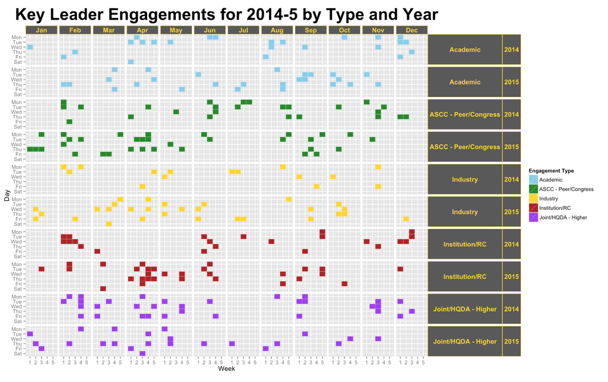

# Example (2 of 2)

- Here is how someone else used it

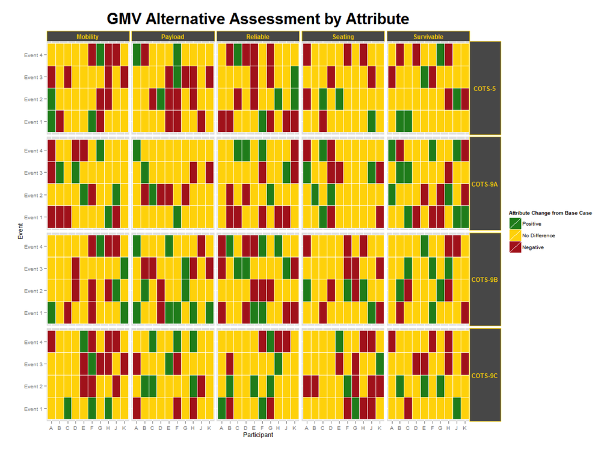

# Exercise

1. File -> New File -> R Markdown
2. Document and HTML
3. This is the basic shell
- Words
- Code
- Plot
4. Go to plot.ly/r/
5. Choose a plot and insert the summary data and plot
6. It’s that easy

# Submitting to DSCOE

1. Have a great idea
2. Have something to share with the community (DoD)
3. Write a tutorial clearly explaining your idea.
4. Put it in the DSCOE format (https://github.com/iankloo/dscoemarkdown)
5. Submit it
6. Be prepared receive gracious gifts from random people.